# ANOVA Practice

```r
library(readr)
library(dplyr)
library(ggplot2)
library(emmeans)
library(multcomp)
```

## Questions

### As we have done before:

1. Make a new project folder (directory) containing a .Rproj file. Use your last name as the first part of the file name (e.g. “Mylastname_ANOVA_practice”).
2. Open a blank script file (.R) and save it in your project folder
3. Copy any data files you need for answering questions into the project folder.
4. Load necessary libraries
5. Make each answer an object (like we did in the previous practices, “quest1 <- code…code…code”)
6. Save each figure as a .png file.
7. Provide a results statement in the format expected in a journal article.

### Practice 1

Medley and Clements (1998) sampled a number of stations (between four and seven) on six streams known to be polluted by heavy metals in the Rocky Mountain Region of Colorado. They recorded zinc concentration, species diversity of the diatom community, and the name of each stream.

`medley.csv` file contents:

**stream** - name of streams in the Rocky Mountain region of Colorado, USA

**zinc_level** - categorical zinc concentration level (HIGH=high, MED=medium, LOW=low, BACK=background)

**diversity** - Shannon-Wiener species diversity of diatoms

**reference_number** - alternative categorical zinc concentration level (1=background, 2=low, 3=medium, 4=high)

Using the `medley.csv` data set,

1. Determine whether the mean diatom species diversity differs across the four zinc-level groups
2. Determine whether different levels of zinc pollution differ in their effect on diatom species diversity
3. Present a bar chart figure depicting means and standard errors for the four levels of pollution.
4. Arrange the bars to proceed in ascending order of pollution (B < L < M < H). Hint, after importing the data, immediately change the order of factor levels (the default is alphabetical, but that doesn’t make sense here).

```r
#Reorder the factor levels to be more intuitive.
medley$zinc_level <- factor(medley$zinc_level, levels = c('BACK', 'LOW', 'MED', 'HIGH'))
#check to make sure they were reordered
unique(medley$zinc_level)
```

```
## [1] LOW  MED  BACK HIGH
## Levels: BACK LOW MED HIGH
```

Start by visualizing the data, easiest methods are a point plot and a box plot (doesn’t require you to summarize data first).

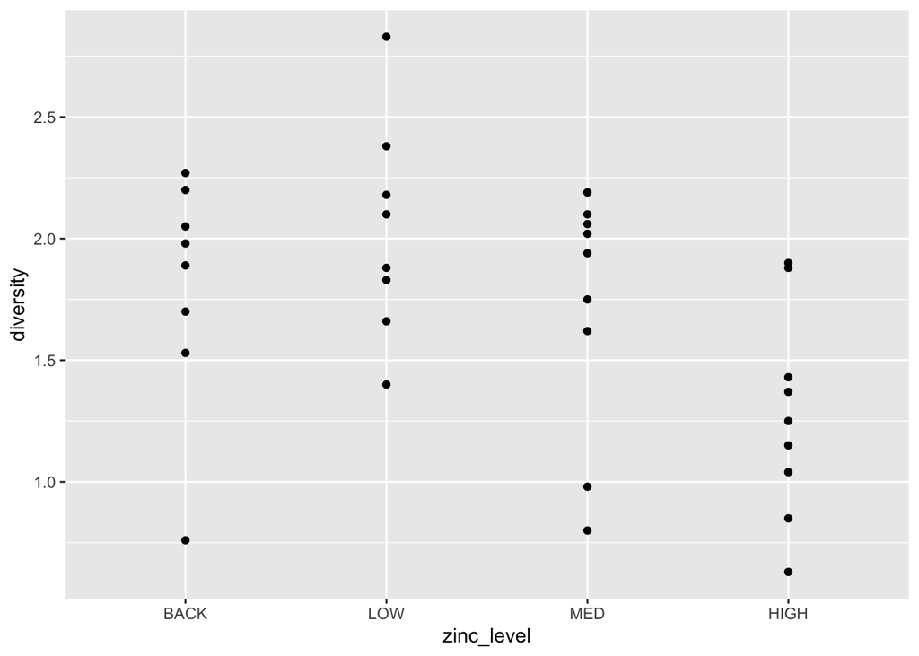

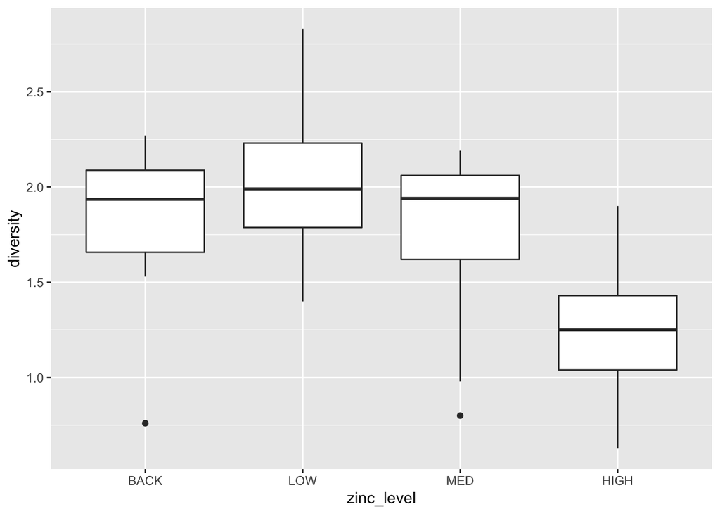

These figures don’t actually help visualize differences all that much, especially because there are some potential outliers that are tricking our eye and no error bars to help visually determine pairwise group differences. Lets summarize the data so we can display the means and error bars. If your levels of zinc are in a different order (such as alphabetical), then you didn’t properly re-level the categorical `zinc_level` variable.

```
## # A tibble: 4 × 5
##   zinc_level  mean     n    sd    se
##   <fct>      <dbl> <int> <dbl> <dbl>
## 1 BACK        1.80     8 0.485 0.172
## 2 LOW         2.03     8 0.445 0.157
## 3 MED         1.72     9 0.503 0.168
## 4 HIGH        1.28     9 0.427 0.142
```

Now that we have summary statistics for the `medley` data set, we can make a more informative figure.

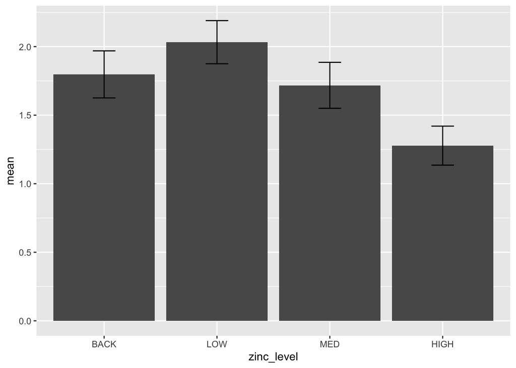

```
##
## Call:
## lm(formula = diversity ~ zinc_level, data = medley)
##
## Residuals:
##      Min       1Q   Median       3Q      Max
## -1.03750 -0.22896  0.07986  0.33222  0.79750
##
## Coefficients:
##                Estimate Std. Error t value Pr(>|t|)
## (Intercept)     1.79750    0.16478  10.909 5.81e-12 ***
## zinc_levelLOW   0.23500    0.23303   1.008   0.3213
## zinc_levelMED  -0.07972    0.22647  -0.352   0.7273
## zinc_levelHIGH -0.51972    0.22647  -2.295   0.0289 *
## ---
## Signif. codes:  0 '***' 0.001 '**' 0.01 '*' 0.05 '.' 0.1 ' ' 1
##
## Residual standard error: 0.4661 on 30 degrees of freedom
## Multiple R-squared:  0.2826, Adjusted R-squared:  0.2108
## F-statistic: 3.939 on 3 and 30 DF,  p-value: 0.01756
```

From the ANOVA report at the bottom, there appears to be overall differences (p = 0.017) in diversity among the streams with different concentrations of zinc. This indicates that *at least one stream* is significantly different from the others in species diversity (reject null hypothesis that all stream types have the same diversity).

Now we use the `emmeans` package to make pairwise comparisons among the four stream types.

```
##  contrast    estimate    SE df t.ratio p.value
##  BACK - LOW   -0.2350 0.233 30  -1.008  0.7457
##  BACK - MED    0.0797 0.226 30   0.352  0.9847
##  BACK - HIGH   0.5197 0.226 30   2.295  0.1219
##  LOW - MED     0.3147 0.226 30   1.390  0.5153
##  LOW - HIGH    0.7547 0.226 30   3.333  0.0117
##  MED - HIGH    0.4400 0.220 30   2.003  0.2096
##
## P value adjustment: tukey method for comparing a family of 4 estimates
```

It looks like the only significant difference in species diversity was between the LOW and HIGH zinc streams (p = 0.011). Lets do a quick plot to visualize this difference. Yep, no overlap between error bars of LOW and HIGH groups.

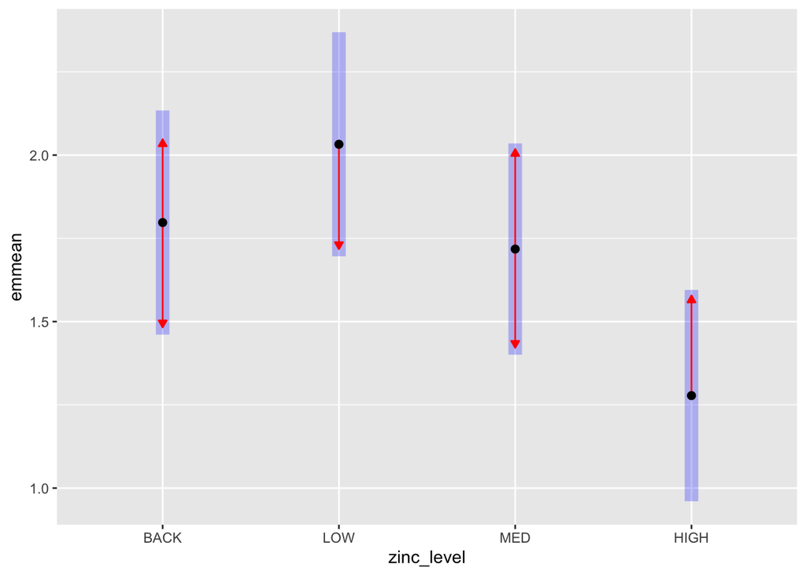

Now we can try to describe all pairwise comparisons among groups ourselves, or we can use a Connecting Letters Differences (CLD) report to help.

```
##  zinc_level emmean    SE df lower.CL upper.CL .group
##  HIGH         1.28 0.155 30    0.961     1.60  a
##  MED          1.72 0.155 30    1.401     2.04  ab
##  BACK         1.80 0.165 30    1.461     2.13  ab
##  LOW          2.03 0.165 30    1.696     2.37   b
##
## Confidence level used: 0.95
## P value adjustment: tukey method for comparing a family of 4 estimates
## significance level used: alpha = 0.05
## NOTE: Compact letter displays can be misleading
##       because they show NON-findings rather than findings.
##       Consider using 'pairs()', 'pwpp()', or 'pwpm()' instead.
```

Transcribe the group letters onto the bar chart you made previously. Be careful, the `multcomp` package does not respect the reordering of levels you did previously; it sorts groups by lowest to highest mean. Transcribe letters carefully.

(*Sidenote: Can you think of a way of forcing R to sort the CLD report by your re-leveled `zinc_level` variable rather than by the default of increasing `emmean`?*)

If you previously made the chart an object (like you should always do) then it will be easy to call up here and add text annotations or text boxes depicting differences among streams.

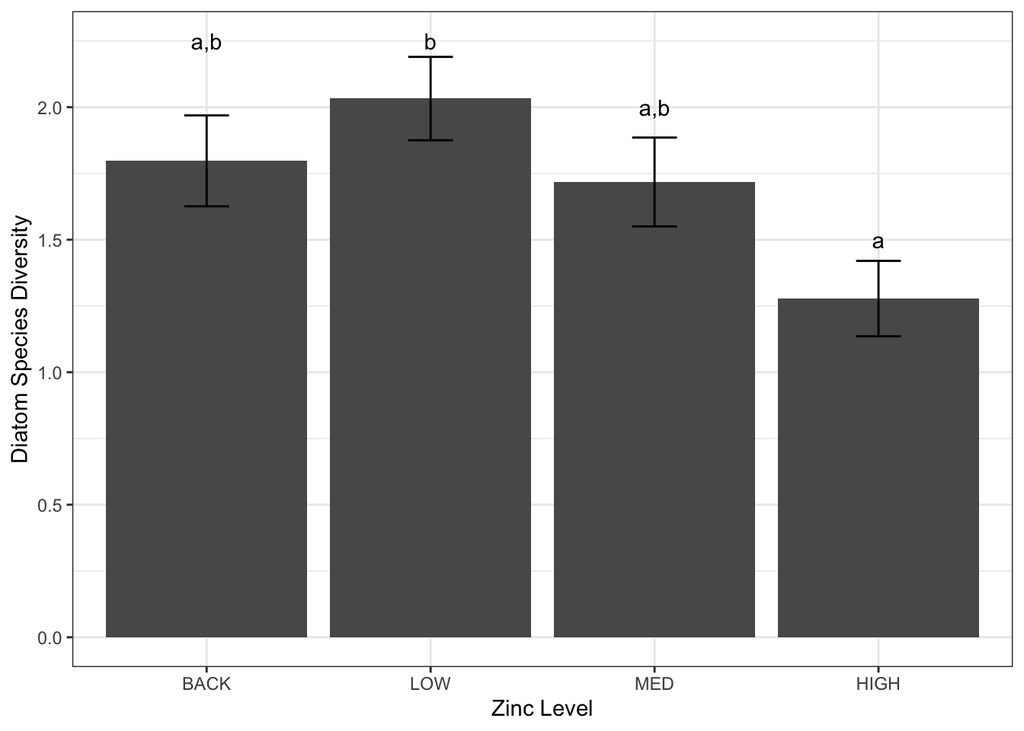

```r
p1 +
  annotate("text", x=4, y=1.5, label="a") +    #HIGH
  annotate("text", x=3, y=2, label="a,b") +    #MED
  annotate("text", x=1, y=2.25, label="a,b") + #BACK
  annotate("text", x=2, y=2.25, label="b") +  #LOW
  #make plot pretty
  xlab("Zinc Level") +
  ylab("Diatom Species Diversity") +
  theme_bw()
```